# Solutions_Ramon_Schildknecht_RTP Excercise Sheet - Series 5

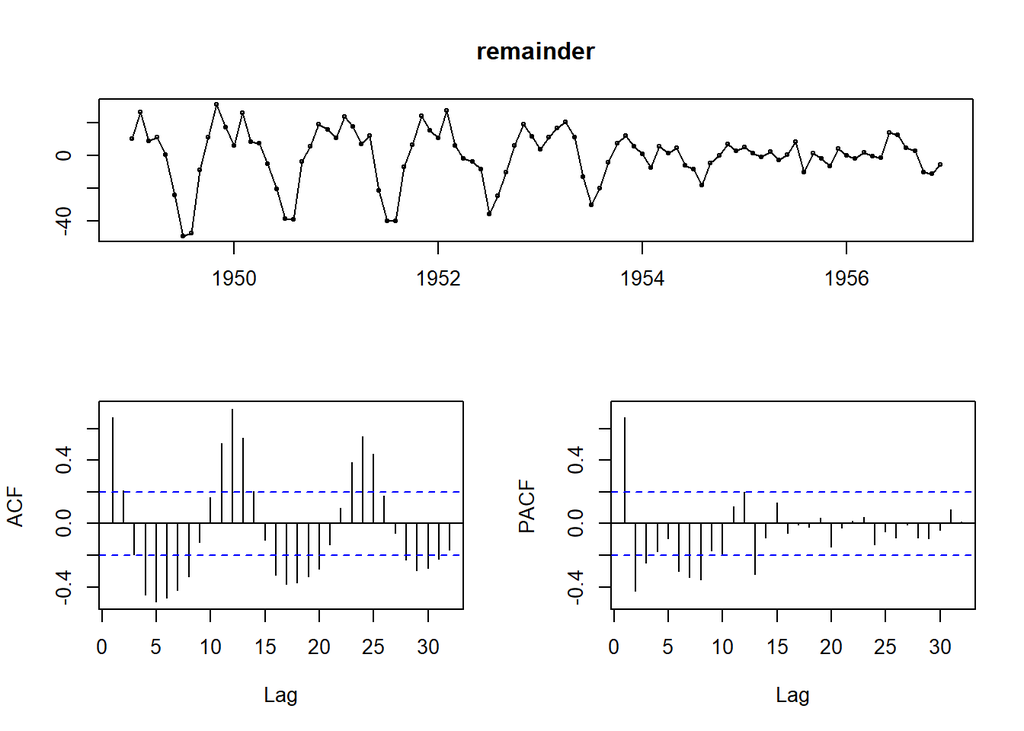

```r
# remainder fitting
tsdisplay(remainder)
```

```r
remainder_coefficients <- auto.arima(remainder, ic = "aic")
remainder_coefficients2 <- auto.arima(remainder, ic = "bic")
remainder_coefficients3 <- auto.arima(remainder, ic = "aicc")
remainder_coefficients
```

```
## Series: remainder
## ARIMA(3,0,1)(1,1,0)[12]
##
## Coefficients:
##          ar1      ar2      ar3      ma1     sar1
##       1.1110  -0.2515  -0.1999  -0.8640  -0.2636
## s.e.  0.1972   0.1837   0.1406   0.2002   0.1088
##
## sigma^2 estimated as 55.75:  log likelihood=-286.45
## AIC=584.9   AICc=585.99   BIC=599.49
```

```r
remainder_coefficients2
```

```
## Series: remainder
## ARIMA(1,0,0)(0,1,0)[12]
##
## Coefficients:
##          ar1
##       0.3241
## s.e.  0.1034
##
## sigma^2 estimated as 66.53:  log likelihood=-295.04
## AIC=594.09   AICc=594.24   BIC=598.95
```

```r
remainder_coefficients3
```

```
## Series: remainder
## ARIMA(1,0,0)(1,1,0)[12]
##
## Coefficients:
##          ar1     sar1
##       0.3633  -0.1955
## s.e.  0.1039   0.1102
##
## sigma^2 estimated as 64.56:  log likelihood=-293.52
## AIC=593.05   AICc=593.35   BIC=600.34
```

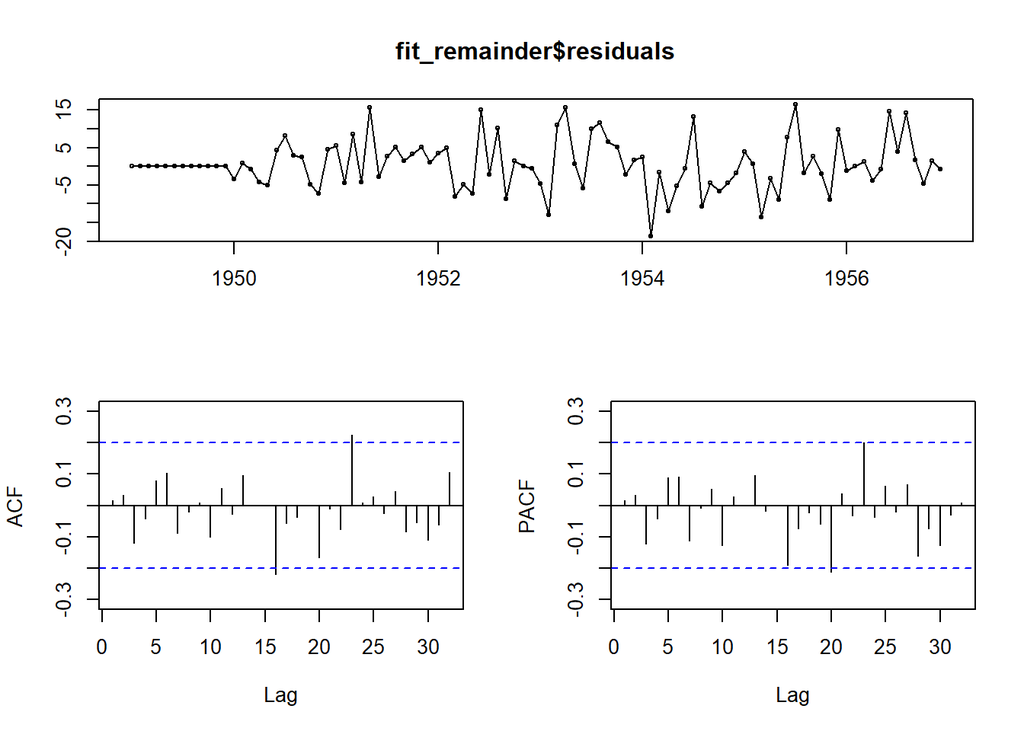

```r
fit_remainder <- arima(remainder, order = c(3, 0, 1), seasonal = c(1, 1, 0), include.mean = F)
tsdisplay(fit_remainder$residuals)
```

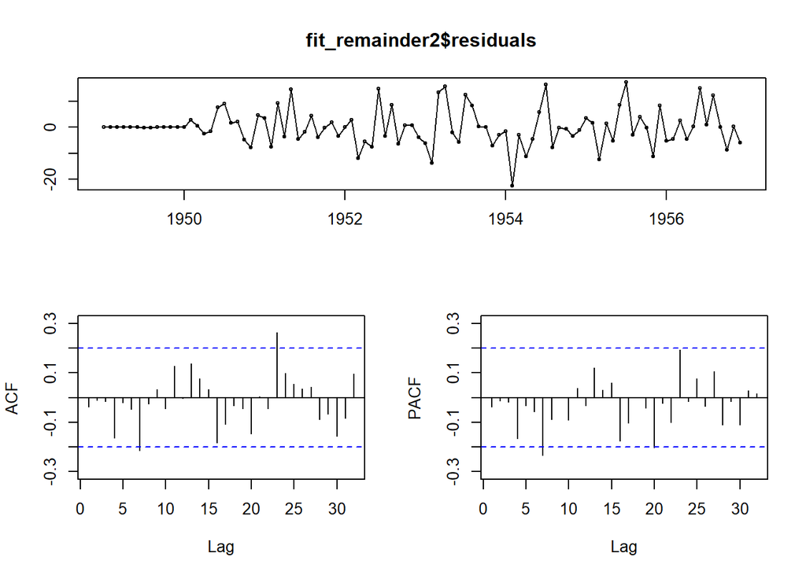

```r
fit_remainder2 <- arima(remainder, order = c(3, 1, 1), seasonal = c(1, 1, 0), include.mean = F)
tsdisplay(fit_remainder2$residuals) # differencing does not improve the result
```

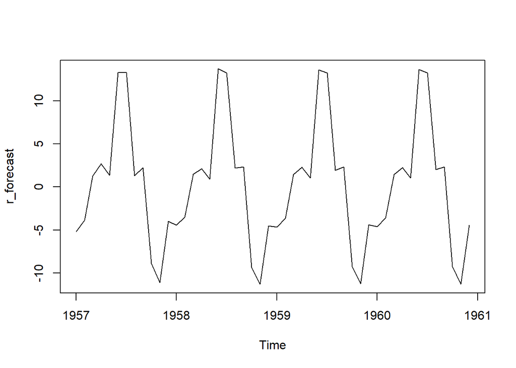

```r
r_forecast <- predict(fit_remainder, n.ahead = 48)$pred
plot(r_forecast)
```

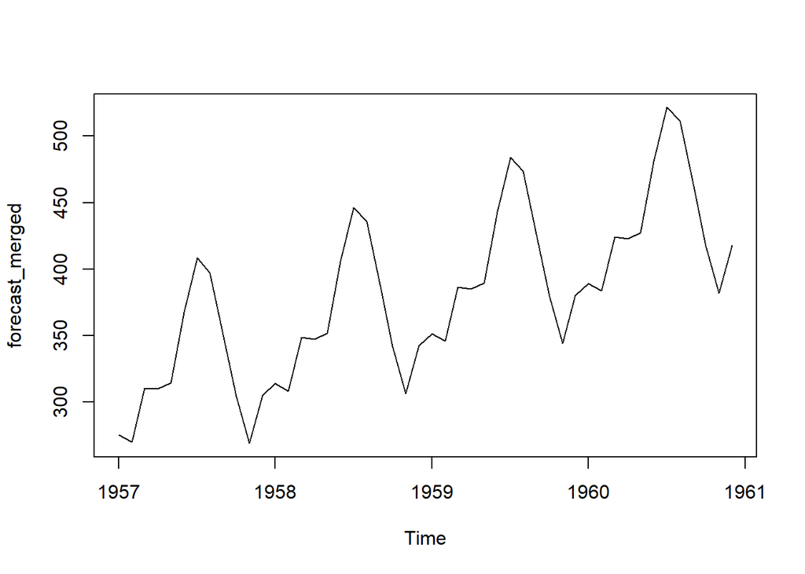

```r
forecast_merged <- t_forecast + s_forecast + r_forecast
plot(forecast_merged)
```

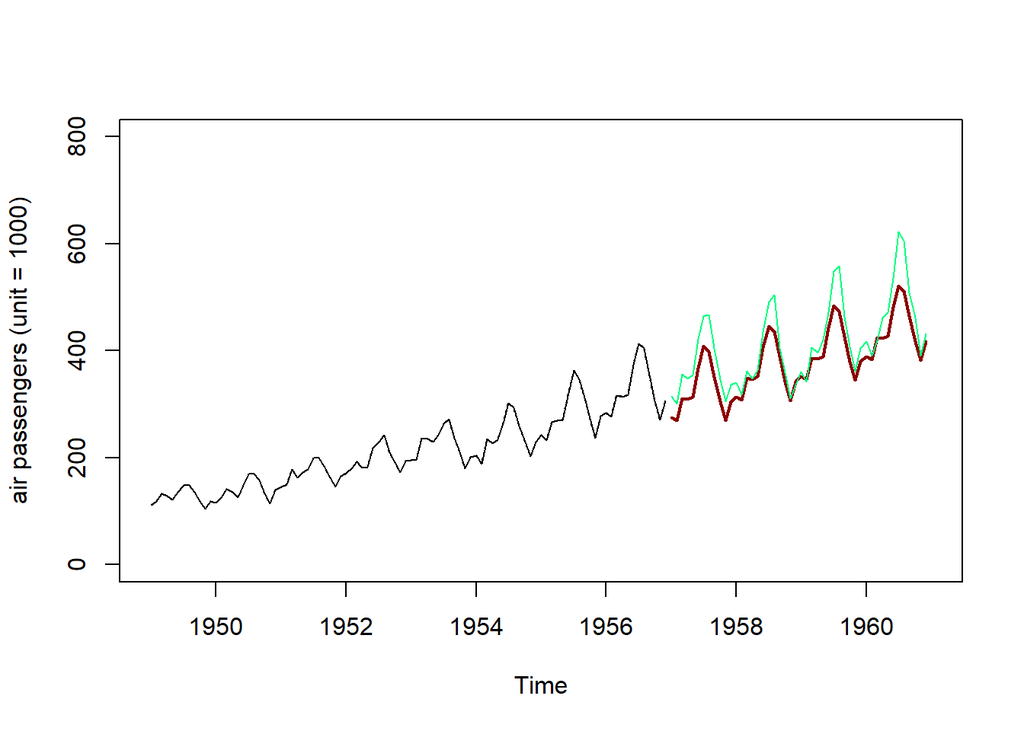

```r
plot(d_1949_to_1956, lty = 3, xlim = c(1949, 1961), ylim = c(0, 800), ylab = "air passengers (unit = 1000)")
lines(d_1949_to_1956, lwd = 1)
lines(forecast_merged, lwd = 2, col = "darkred")
lines(window(d, start = c(1957, 01), lwd = 2, end = c(1960, 12)), col = "springgreen")
```

The model delivers quite accurate results. The residuals are allright.  
I don’t know if my intercept of 306 was choosen rightly? This value has a huge impact on the model results.

One does not need a prediction interval with this method. Reason: The method uses partly the acutal data to generate the predictions.

The SARIMA model is more accurate and is therefore the better solution for fitting the airplane data. Both models could improve by fitting the seasonal peaks even better.